# Lab 4

March 2, 2018

RStudio keeps track of the code chunks in the document (see the menu near the bottom left of the code window, to the right of the “line number:column number” counter). Optionally, you can give any chunk a name, for instance “Setup” below. This can make it easier to navigate the code chunks afterwards.

# Data wrangling

## 1

Let us first inspect the two data sets

| date | phid | chain | storesize | sale | nobs | packages | market |
| --- | --- | --- | --- | --- | --- | --- | --- |
| 2004-03-01 | 1 | 1 | 450 | 2061176.6 | 4358 | 6029.900 | 0 |
| 2004-03-01 | 2 | 2 | 539 | 1850057.4 | 3999 | 5971.000 | 1 |
| 2004-03-01 | 3 | 1 | 419 | 787220.7 | 1773 | 2359.000 | 2 |
| 2004-03-01 | 4 | 3 | 583 | 1493831.8 | 2567 | 3654.106 | 3 |
| 2004-03-01 | 5 | 2 | 257 | 1249405.1 | 2514 | 3552.300 | 3 |
| 2004-03-01 | 6 | 2 | 273 | 1822493.5 | 3601 | 5292.506 | 3 |
| 2004-03-01 | 11 | 1 | 122 | 1184325.7 | 2752 | 3764.821 | 5 |
| 2004-03-01 | 12 | 3 | 400 | 2241024.9 | 4796 | 6431.000 | 6 |
| 2004-03-01 | 14 | 2 | 105 | 496317.1 | 1035 | 1307.800 | 7 |
| 2004-03-01 | 15 | 2 | 156 | 650308.2 | 1561 | 2143.286 | 8 |

[output cut: 990 more lines]

| year | market | area | f0_19 | f20_66 | f67. | m0_19 | m20_66 | m67. |
| --- | --- | --- | --- | --- | --- | --- | --- | --- |
| 2004 | 0 | 10.640 | 2095.0 | 4731.0 | 1265.0 | 2109.0 | 4767.0 | 907.0 |
| 2005 | 0 | 10.640 | 2065.0 | 4768.0 | 1303.0 | 2124.0 | 4784.0 | 933.0 |
| 2006 | 0 | 10.760 | 2034.0 | 4738.0 | 1315.0 | 2091.0 | 4786.0 | 946.0 |
| 2007 | 0 | 10.800 | 2006.0 | 4721.0 | 1327.0 | 2056.0 | 4961.0 | 973.0 |
| 2008 | 0 | 10.860 | 1998.0 | 4722.0 | 1352.0 | 2091.0 | 4824.0 | 993.0 |
| 2009 | 0 | 10.870 | 1975.0 | 4722.0 | 1375.0 | 2070.0 | 4775.0 | 1006.0 |
| 2010 | 0 | 10.925 | 1959.0 | 4736.5 | 1396.5 | 2059.5 | 4781.5 | 1039.0 |
| 2011 | 0 | 10.980 | 1943.0 | 4751.0 | 1418.0 | 2049.0 | 4788.0 | 1072.0 |
| 2004 | 1 | 9.940 | 1980.0 | 3779.0 | 635.0 | 2005.0 | 3877.0 | 380.0 |
| 2005 | 1 | 9.970 | 1953.0 | 3798.0 | 648.0 | 2056.0 | 3887.0 | 401.0 |

[output cut: 990 more lines]

We want to combine the information in the two data sets. More specifically, we want to add information about the market to each row in the stores data frame. This is achieved by an left join. In order to perform the join we need to extract the year rom the stores data, since we will join using the combination of market and year as key.

`r`r stores <- mutate(stores, year = year(date))

A `left_join(x,y, by = key)` keeps all observations in “X”. A right join would keep all observations in “y”, while a full join would keep all observations in “x” and “y”. For more information, see chapter 13 in R for Data Science.

## 2

We want to create a variable with the number of pharmacies in a given market in a given month. First, let us confirm that our data sets contain at most one observation per pharmacy per month

`r`r count(stores, date, phid) %>% summarise(max(n))

| max(n) |
| --- |
| 1 |

## 3

# Present and understand your data

## 4

Summary statistics: A good option is to use the *stargazer* package

## 5

When we have many observations, a plain-vanilla scatter is not that informative:

`r`r ggplot(data = stores) + geom_point(mapping = aes(x = nobs, y = sale))

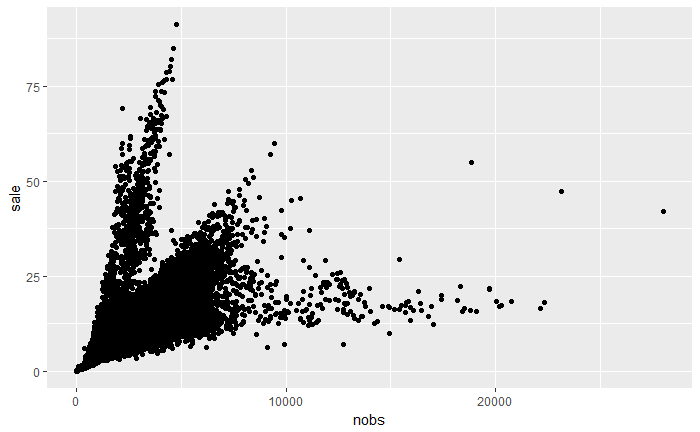

Making the points partially transparent helps a bit (but not that much):

`r`r ggplot(data = stores) + geom_point(mapping = aes(x = nobs, y = sale), alpha = .05)

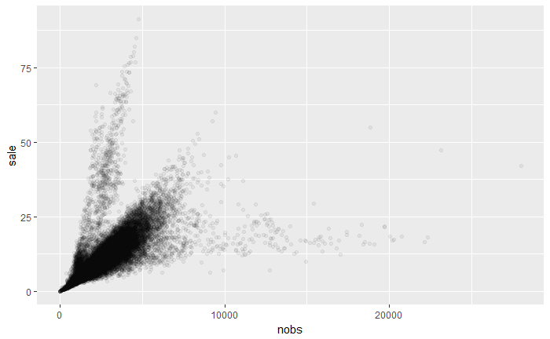

A useful variant of a scatter plot is a binscatter (available through the *statar* package). A binscatter plots average values of the y-variable for within bins of the x-variable:

`r`r ggplot(data = stores, mapping = aes(x = nobs, y = sale)) + stat_binmean(n = 50, alpha = 0.5)

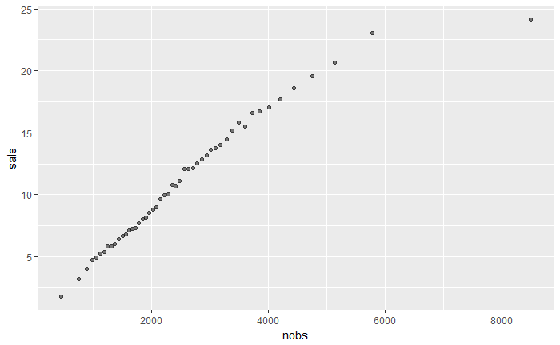

## 6

Hint: use `facet_wrap`

# Estimation

## 12

# Extra

## a

## b

## c

## d

## e

## f